# Higher Education in 2018-2019

Author

Kelsey Pearson

This report shows how the University of Edinburgh compares with the University of Aberdeen, the University of Glasgow, the University of Strathclyde and the University of St Andrews in 2018-2019.

The following topics are included:

- Number of Undergraduate and Postgraduate Taught students
- The ratio of students to staff (‘SSR’)
- Income to University per academic staff member

## Data sources

The data used in this report is available from the The Higher Education Statistics Agency (HESA) at https://www.hesa.ac.uk/data-and-analysis.

Links to data:

- Student data: https://www.hesa.ac.uk/data-and-analysis/students/table-1.csv
- Staff data: https://www.hesa.ac.uk/data-and-analysis/staff/table-1.csv
- Finance data: https://www.hesa.ac.uk/data-and-analysis/finances/table-1.csv

This report was made using R and the script can be found here:

- https://github.com/kjp07/HE-2018-2019.git

## Number of Undergraduate and Postgraduate Taught students

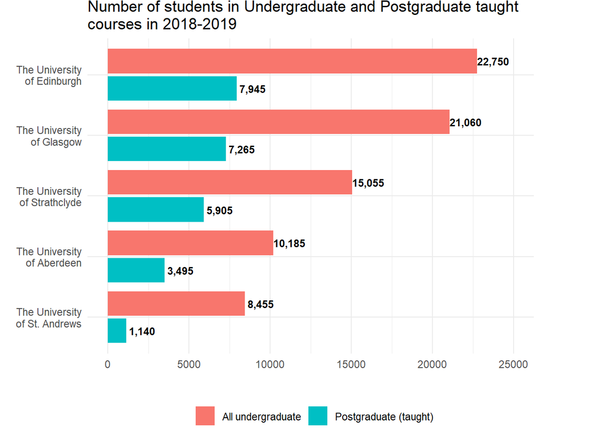

Number of students in Undergraduate and Postgraduate taught courses in 2018-2019

| HE Provider | Postgraduate (taught) | Undergraduate | Total |
| --- | --- | --- | --- |
| The University of Edinburgh | 7,945 | 22,750 | 30,695 |
| The University of Glasgow | 7,265 | 21,060 | 28,325 |
| The University of Strathclyde | 5,905 | 15,055 | 20,960 |
| The University of Aberdeen | 3,495 | 10,185 | 13,680 |
| The University of St. Andrews | 1,140 | 8,455 | 9,595 |

In 2018-2019, The University of Edinburgh had the largest student population with 30,695 students. The University also had the largest number of students studying at Undergraduate and in Postgraduate taught courses, with 22,750 and 7,945 students respectively.

In the same year, The University of St. Andrews had the smallest student population with 9,595 students studying in Undergraduate level (8,455) and in Postgraduate Taught courses (1,140).

## Ratio of students to staff (‘SSR’)

Atypical staff are members of staff who contracts involve non-permenant working arrangements. This group has been excluded from the analysis below because of this.

### All students and all staff (excluding atypical)

In 2018-2019, The University of Edinburgh had the greatest number of staff members out of the five universities, with 14,410 members of staff. The University of St. Andrews had the smallest staff population with 2,775.

The University of Edinburgh also had the largest student body of the five universities, with 34,275 students. The University of St. Andrews had the smallest student population with 10,570.

However, The University of Strathclyde had the largest SSR with 5.88 students per member of staff, whilst The University of Edinburgh had the smallest SSR, with 2.38 students per member of staff.

SSR when considering all students and all staff (excluding atypical) in 2018-2019

| HE Provider | Students | Staff | SSR |
| --- | --- | --- | --- |
| The University of Edinburgh | 34,275 | 14,410 | 2.38 |
| The University of St. Andrews | 10,570 | 2,775 | 3.81 |
| The University of Glasgow | 30,805 | 8,015 | 3.84 |
| The University of Aberdeen | 14,775 | 3,230 | 4.57 |
| The University of Strathclyde | 22,640 | 3,850 | 5.88 |

### All students to all full-time academic staff (excluding atypical)

Full-time academic staff may have the greatest interaction with students compared with part-time academic staff. The analysis below considers all students and full-time academic staff (excluding atypical).

The University of Edinburgh’s has the smallest student to academic staff ratio, with 8.82 students per academic staff member. This is approximately half the SSR of the The University of Strathclyde’s SSR, which is has the largest SSR with 15.89 students per academic staff member.

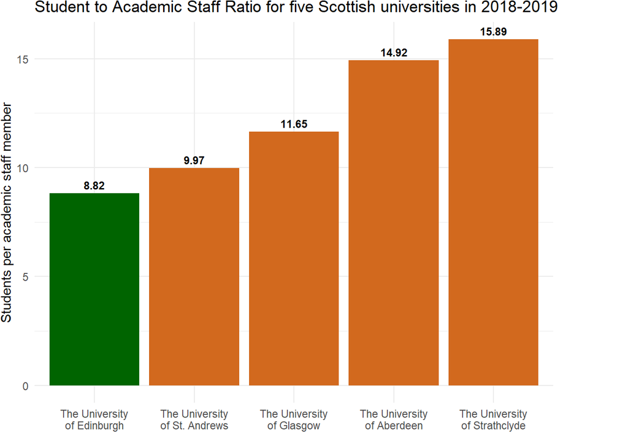

SSR when considering all students and full-time academic staff in 2018-2019

| HE Provider | Students | Academic staff | SSR |
| --- | --- | --- | --- |
| The University of Edinburgh | 34,275 | 3,885 | 8.82 |
| The University of St. Andrews | 10,570 | 1,060 | 9.97 |
| The University of Glasgow | 30,805 | 2,645 | 11.65 |
| The University of Aberdeen | 14,775 | 990 | 14.92 |
| The University of Strathclyde | 22,640 | 1,425 | 15.89 |

## Income to University per academic staff member

In 2018-2019, The University of Edinburgh had the largest income (£1,101,504) and £283.53 per academic staff member.

However, there’s a difference of £52.73 between the full-time academic staff at The University of Edinburgh and The University of Aberdeen.

Income per academic staff member in 2018-2019 (sorted by income per academic staff member)

| HE Provider | Academic staff | Total income | Income per academic staff member |
| --- | --- | --- | --- |
| The University of Edinburgh | 3,885 | £1,101,504 | £283.53 |
| The University of Glasgow | 2,645 | £ 687,896 | £260.07 |
| The University of St. Andrews | 1,060 | £ 257,448 | £242.88 |
| The University of Strathclyde | 1,425 | £ 336,216 | £235.94 |
| The University of Aberdeen | 990 | £ 228,494 | £230.8 |

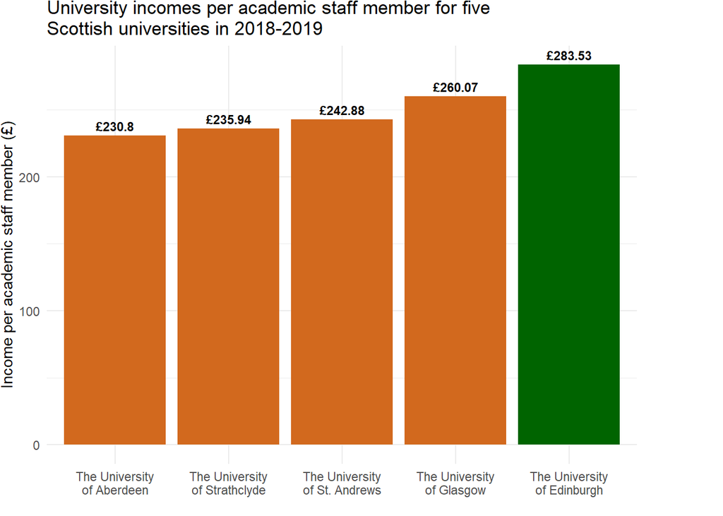